# gnomonicM: An R Package to Estimate Natural Mortality for different life stages

Josymar Torrejon-Magallanes, Francisco Arreguin-Sanchez, Enrique Morales-Bojorquez

2020-05-24

This vignette introduces you to `gnomonicM` package and provide a way to estimate **Natural Mortality (M) throughout the life history of species**, mainly fish and invertebrates.

### Install package

The package is in the developing phase. You can install from CRAN:

```r
install.packages("gnomonicM")
```

Or the development version from github:

```r
# install.packages("devtools")
devtools::install_github("ejosymart/gnomonicM")
```

### 1. Natural mortality (M) via deterministic method

For estimating *M* we will use the data provided by Caddy (1996) based in a species with: 7 gnomonic intervals, egg stage duration of 2 days, a lifespan of one year (365 days), a mean lifetime fecundity (*MLF*) of 200 000 eggs and a initial constant proportionality ($\alpha$) value of 2.

```r
model <- gnomonic(nInterval   = 7,
                  eggDuration = 2,
                  longevity   = 365,
                  fecundity   = 200000,
                  a_init      = 2)
```

If you have additional information related to the duration of the others gnomonic intervals you could provide this in the argument `addInfo`. For example, we assume that the duration of the second and fifth gnomonic interval is equal to 4 and 40 days respectively, so we have to include this information as follows:

```r
modelAddInfo <- gnomonic(nInterval   = 7,
                         eggDuration = 2,
                         addInfo     = c(4, NA, NA, 40, NA, NA),
                         longevity   = 365,
                         fecundity   = 200000,
                         a_init      = 2)
```

The `NA` values in the argument `addInfo` should be written to complete the length of the vector, in this case the length of the vector is equal to `nInterval` - 1.

### Print and plot for deterministic method

For plotting, an object of class `gnomos` is required. The function `plot` generates a scatter plot with the values of *M* for each gnomonic interval. You can modify the labels via `xlab`, `ylab`, the color via `bg` and the sizes of points in the scatter plot, also you can pass arguments to the plot method.

```r
#No additional information in the duration of gnomonic intervals
print(model)
```

```
## The value of proportionality constant (alpha) = 1.381646
##
## --------------------------------------------------------
##
## The value of constant proportion of the overall natural death rate (G) = 1.644704
##
## --------------------------------------------------------
##
## Main results of gnomonic method:
##
##   Gnonomic_interval interval_duration_day total_duration M_day  M_year No_Surv
## 1                 1                 2.000              2 0.822 300.158   38614
## 2                 2                 2.763              5 0.595 217.247    7455
## 3                 3                 6.581             11 0.250  91.217    1439
## 4                 4                15.674             27 0.105  38.300     278
## 5                 5                37.330             64 0.044  16.081      54
## 6                 6                88.907            153 0.018   6.752      10
## 7                 7               211.745            365 0.008   2.835       2
```

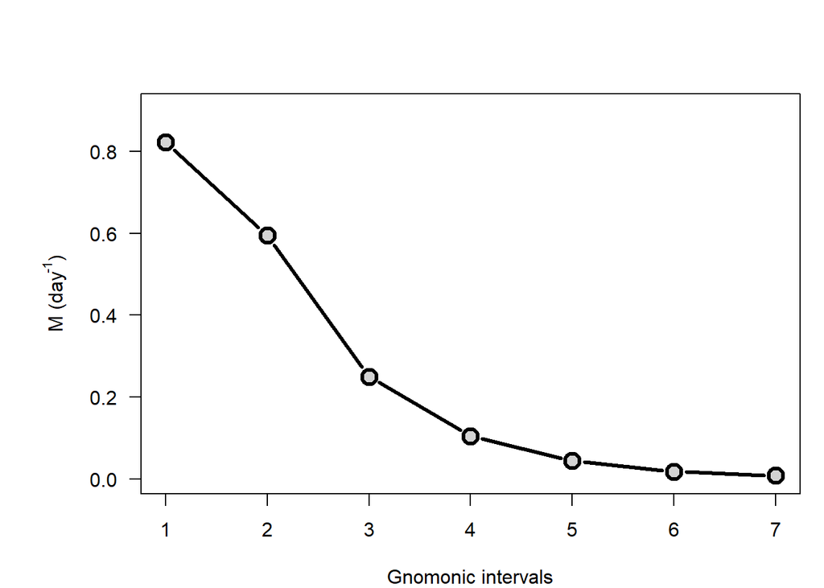

```r
plot(model)
```

```r
#With additional information in the duration of gnomonic intervals
print(modelAddInfo)
```

```
## The value of proportionality constant (alpha) = 1.376991
##
## --------------------------------------------------------
##
## The value of constant proportion of the overall natural death rate (G) = 1.644704
##
## --------------------------------------------------------
##
## Main results of gnomonic method:
##
##   Gnonomic_interval interval_duration_day total_duration M_day  M_year No_Surv
## 1                 1                 2.000              2 0.822 300.158   38614
## 2                 2                 4.000              6 0.411 150.079    7455
## 3                 3                 6.546             13 0.251  91.705    1439
## 4                 4                15.560             28 0.106  38.580     278
## 5                 5                40.000             68 0.041  15.008      54
## 6                 6                87.917            156 0.019   6.828      10
## 7                 7               208.977            365 0.008   2.873       2
```

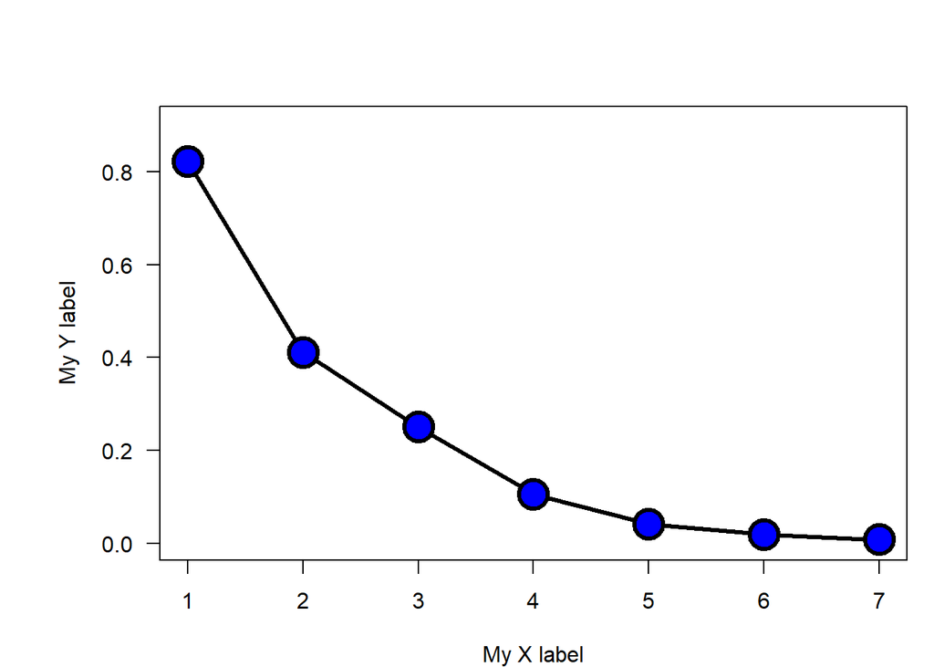

```r
plot(modelAddInfo, xlab = "My X label", ylab = "My Y label", cex = 3, bg = "blue")
```

### 2. Natural mortality (M) via stochastic method

The function to be used to estimate *M* is `gnomonicStochastic`. In the previous estimation of natural mortality based on the `gnomonic` function did not include any measures of deviation. In this method we calculated these measures, assuming that the main source of uncertainty and variability was the mean lifetime fecundity (*MLF*).

We have included (until now) three different distribution function via the argument `distr`. It could be `distr = 'normal'`, `distr = 'uniform'` and `distr = 'triangle'`. Once you choose a particular distribution function, you must to include additional information related with the minimum, maximum, mean and standard deviation (sd) of *MLF*.

We will use the same information of the above examples but including uncertainty in the argument `fecundity` (*MLF*). In the following cases, we simulated 1000 estimates of natural mortality for each gnomonic intervals and estimated mean mortality rate ($\bar{M_i}$), the confidence interval and the standard error was represented by the standard deviation ($\sigma_{i}$).

```r
modelUniform <- gnomonicStochastic(nInterval     = 7,
                                   eggDuration   = 2,
                                   longevity     = 365,
                                   distr         = "uniform",
                                   min_fecundity = 100000,
                                   max_fecundity = 300000,
                                   niter         = 1000,
                                   a_init        = 2)
```

```
## [1] "You are using a 'uniform distribution' for fecundity"
```

```r
modelUniformAddInfo <- gnomonicStochastic(nInterval     = 7,
                                          eggDuration   = 2,
                                          addInfo       = c(4, NA, NA, 40, NA, NA),
                                          longevity     = 365,
                                          distr         = "uniform",
                                          min_fecundity = 100000,
                                          max_fecundity = 300000,
                                          niter         = 1000,
                                           a_init        = 2)
```

```
## [1] "You are using a 'uniform distribution' for fecundity"
```

```r
modelNormal <- gnomonicStochastic(nInterval     = 7,
                                  eggDuration   = 2,
                                  longevity     = 365,
                                  distr         = "normal",
                                  fecundity     = 200000,
                                  sd_fecundity  = 50000,
                                  niter         = 1000,
                                  a_init        = 2)
```

```
## [1] "You are using a 'normal distribution' for fecundity"
```

```r
modelTriangle <- gnomonicStochastic(nInterval     = 7,
                                    eggDuration   = 2,
                                    longevity     = 365,
                                    distr         = "triangle",
                                    fecundity     = 200000,
                                    min_fecundity = 100000,
                                    max_fecundity = 300000,
                                    niter         = 1000,
                                    a_init        = 2)
```

```
## [1] "You are using a 'triangular distribution' for fecundity"
```

### Print and plot for stochastic method

Printing and plotting the result of the stochastic method follow the same idea that deterministic method. The difference in print is that result includes the *niter* values of *G* and *fecundity*, and the M values for each gnomonic intervals for each iteration. The plot is based on a boxplot and the arguments could be modified as in the deterministic method.

```r
#The results are not shown.
print(modelUniform)
```

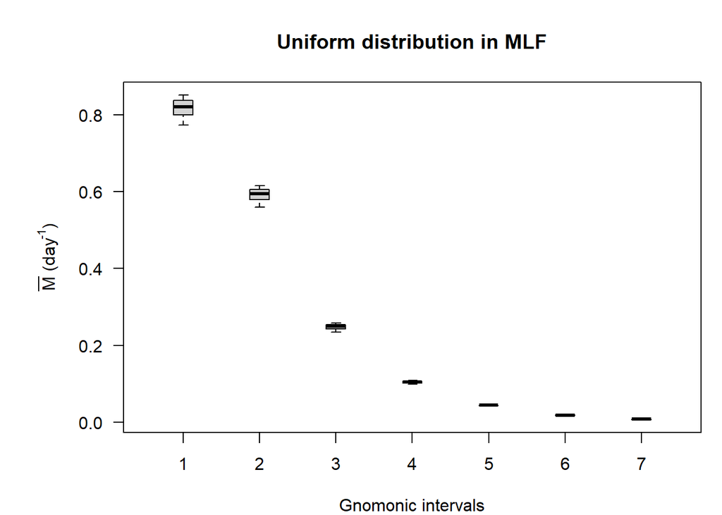

```r
plot(modelUniform, main = "Uniform distribution in MLF")
```

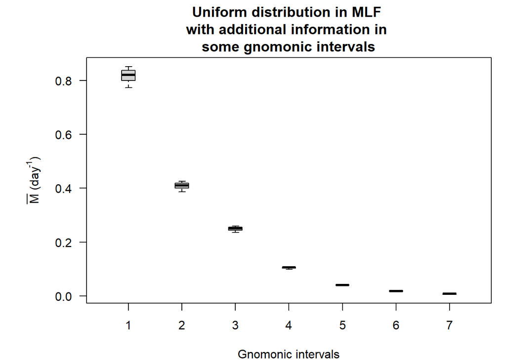

```r
plot(modelUniformAddInfo, main = "Uniform distribution in MLF \nwith additional information in \nsome gnomonic intervals")
```

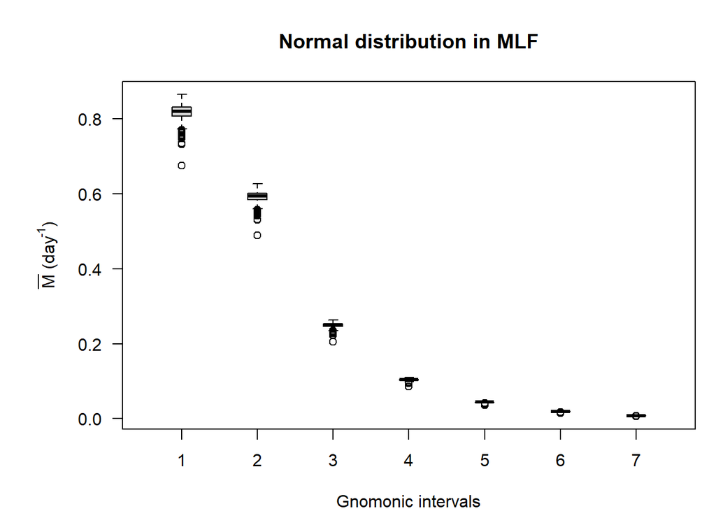

```r
plot(modelNormal, main = "Normal distribution in MLF")
```

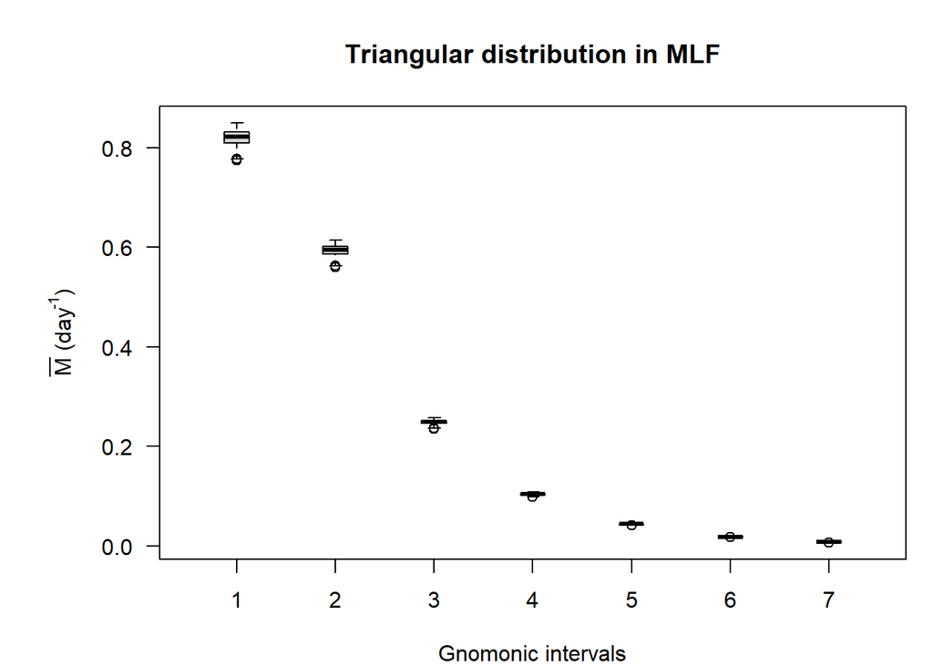

```r
plot(modelTriangle, main = "Triangular distribution in MLF")
```

### References

Caddy JF (1991). Death rates and time intervals: is there an alternative to the constant natural mortality axiom? Reviews in Fish Biology and Fisheries 1:109–138. doi: 10.1007/BF00157581.

Caddy JF (1996). Modelling natural mortality with age in short-lived invertebrate populations: definition of a strategy of gnomonic time division. Aquatic Living Resource 9:197–207. doi: 10.1051/alr:1996023.

Martínez-Aguilar S, Arreguín-Sánchez F, Morales-Bojórquez E (2005). Natural mortality and life history stage duration of Pacific sardine (Sardinops caeruleus) based on gnomonic time divisions. Fisheries Research 71:103–114. doi: 10.1016/j.fishres.2004.04.008.

Torrejon-Magallanes J, Arreguín-Sánchez F, Morales-Bojórquez E (in prep). Natural mortality estimation through the life history of Pacific chub mackerel (Scomber japonicus): a gnomonic approach.